# My Phd Thesis

# Cascade Segmentation - 3 - New analysis

Après la réunion avec Argyris son conseil en bref c’est de monter l’analyse d’une manière incrémentale. c’est à dire commencer par une analyse d’une petite quantité ensuite passer au plus large. Et cela se fait sur 3 niveaux :

- niveau plateforme : analyser les données de chaque plateforme à part
- niveau variables: commencer par des couples de variables (ne pas tout prendre en un seul coup).
- niveau cascades: les analyses par groupe de tailles similaires (les grands ensembles et les petits ensemble) etc..
- Et une question très importante qu’il faut être claire et sur laquelle je n’ai pas pu répondre : Qu’est ce qu’on attend de cette analyse ?

> l’objectif est de savoir si cette méthode nous permet de mieux comprendre et de mieux mesurer la diffusion d’une information sur le web, et quelles sont les variables explicatives, *Christine*

# Data Overview

```r
data <- read.csv("../Radarly_data_clusters/Banque_clusters_gt20.csv",sep=",",fileEncoding = "UTF-8",header=T)
data <- data.table(data)
# change the levels of factory story
data$story <- as.factor(as.vector(data$story))
```

Dimensions :

[output not shown]

Nombre de posts par Plateforme:

```r
pander(table(data$platform))
```

```
 Blog   Facebook   Gplus   Media   Twitter   Website
------ ---------- ------- ------- --------- ---------
 313      1731       1     4623     49864     3487
```

Nombre de posts de chaque cascade:

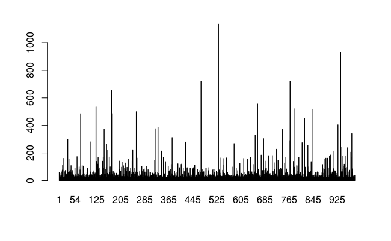

```r
barplot(table(data$story))
```

10 Largest cascades :

```r
pander(sort(table(data$story),decreasing = T)[1:10])
```

```
 530   936   472   768   175   660   123   784   844   474
----- ----- ----- ----- ----- ----- ----- ----- ----- -----
1134   930   722   722   654   556   535   522   519   510
```

10 Smallest cascades :

```r
pander(sort(table(data$story),decreasing = F)[1:10])
```

```
 4   10   15   26   27   34   36   82   121   127
--- ---- ---- ---- ---- ---- ---- ---- ----- -----
21   21   21   21   21   21   21   21   21    21
```

# 1. Plateforme: Twitter

Filtering the data: Subdata with only `platform == Twitter`. Naming it `twitter_data`.

```r
# twitter_data <- data[platform=="Twitter"]
#subsetting
twitter_data <- subset(data, platform=="Twitter")
# factors initialise
twitter_data[] <- lapply(twitter_data, function(x) if(is.factor(x)) factor(x) else x)
```

Twitter_data Dimensions :

[output not shown]

Nombre de posts par Plateforme:

```r
pander(table(twitter_data$platform))
```

```
 Twitter
---------
  49864
```

Nombre de posts de chaque cascade:

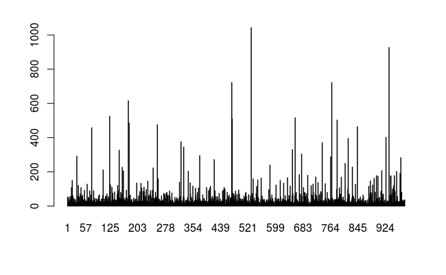

```r
barplot(table(twitter_data$story))
```

10 Largest cascades :

```r
pander(sort(table(twitter_data$story),decreasing = T)[1:10])
```

```
 530   936   472   768   175   123   660   474   784   177
----- ----- ----- ----- ----- ----- ----- ----- ----- -----
1043   927   722   722   616   526   516   510   503   486
```

```r
pander(sort(table(twitter_data$story),decreasing = F)[1:100])
```

```
 87   103   185   602   873   4   69   414   598   248   325   371   700   701
---- ----- ----- ----- ----- --- ---- ----- ----- ----- ----- ----- ----- -----
 1     1     1     1     1    2   2     2     2     3     3     3     3     3

Table: Table continues below



 217   595   616   684   823   924   234   662   775   83   333   405   841
----- ----- ----- ----- ----- ----- ----- ----- ----- ---- ----- ----- -----
  4     4     4     4     4     4     5     5     5    6     6     6     6

Table: Table continues below



 894   527   870   428   708   443   454   79   455   554   937   36   240
----- ----- ----- ----- ----- ----- ----- ---- ----- ----- ----- ---- -----
  6     7     7     8     8     9     9    10   10    10    10    11   11

Table: Table continues below



 596   654   281   302   690   758   947   146   365   670   707   747   910
----- ----- ----- ----- ----- ----- ----- ----- ----- ----- ----- ----- -----
 11    11    12    12    12    12    12    13    13    13    13    13    13

Table: Table continues below



 913   309   326   361   508   521   695   831   862   190   253   261   295
----- ----- ----- ----- ----- ----- ----- ----- ----- ----- ----- ----- -----
 13    14    14    14    14    14    14    14    14    15    15    15    15

Table: Table continues below



 332   555   573   702   811   821   871   432   488   552   571   618   664
----- ----- ----- ----- ----- ----- ----- ----- ----- ----- ----- ----- -----
 15    15    15    15    15    15    15    16    16    16    16    16    16

Table: Table continues below



 682   771   813   834   982   28   82   127   166   171   303   313   407
----- ----- ----- ----- ----- ---- ---- ----- ----- ----- ----- ----- -----
 16    16    16    16    16    17   17   17    17    17    17    17    17

Table: Table continues below



 419   568   569   741   229   244   301   305
----- ----- ----- ----- ----- ----- ----- -----
 17    17    17    17    18    18    18    18
```

As we see above, now we have cascades with only one or two or three posts (since we removed all the other platforms). I will remove small cascades and keep cascades that have more than 20 posts.

> (10 or 15 or 20 ? I dont know)

Lets take a look to the quantiles

```r
pander(quantile(as.vector(table(twitter_data$story))))
```

```
 0%   25%   50%   75%   100%
---- ----- ----- ----- ------
 1    23    31    55    1043
```

- 25% of the cascades have less than 23 posts.
- 25% of the cascades have between 23 and 31 posts.
- 25% of the casades have between 31 and 55 posts.
- 25% of the cascades have more than 55 posts.

I will consider the following:

- big cascades have more than 55 posts.
- small cascades have between 23 and 55 posts.

```r
# first remove cascades with less than 23 posts
twitter_data <- twitter_data[story %in% names(sort(table(twitter_data$story),decreasing = T)[1:sum(table(twitter_data$story)>22)]),]
# here pay attention to decreasing = T, if you want the smallest cascades you must put it decreasing = F.
# re-initialise story factor
twitter_data[] <- lapply(twitter_data, function(x) if(is.factor(x)) factor(x) else x)
```

Verification: Nombre de cascades: 668.

Verification: Nombre de posts de chaque cascade:

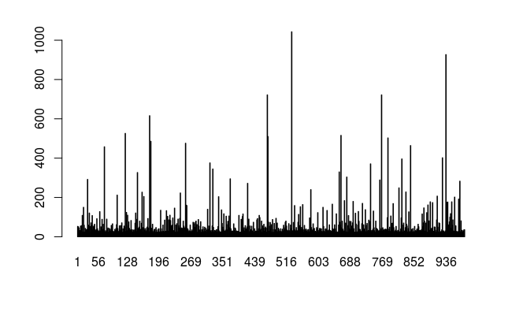

```r
barplot(table(twitter_data$story))
```

Verification: 10 Smallest cascades :

```r
pander(sort(table(twitter_data$story),decreasing = F)[1:10])
```

```
 5   117   181   188   193   197   233   287   297   316
--- ----- ----- ----- ----- ----- ----- ----- ----- -----
23   23    23    23    23    23    23    23    23    23
```

# Small & Big Cascades

Now I will separate the `twitter_data` into two subsets. The first one contains the big cascades and the second one contains the small cascades and I will analyse each one apart.

Lets see the distribution of cascades by their size (nombre of posts in each cascade)

Here is the boxplot

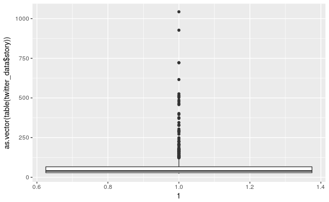

```r
qplot(as.vector(table(twitter_data$story)), x= 1, geom = "boxplot")
```

I will do the following:

- dataset `twitter_data_big`: big cascades have more than 55 posts.
- dataset `twitter_data_small`: small cascades have between 23 and 55 posts.

## `twitter_data_big`

```r
twitter_data_big <- twitter_data[story %in% names(sort(table(twitter_data$story),decreasing = T)[1:sum(table(twitter_data$story)>55)]),]
# re-initialise story factor
twitter_data_big[] <- lapply(twitter_data_big, function(x) if(is.factor(x)) factor(x) else x)
```

Nombre de cascades dans `twitter_data_big`: 217.

Nombre de posts de chaque cascade de `twitter_data_big`:

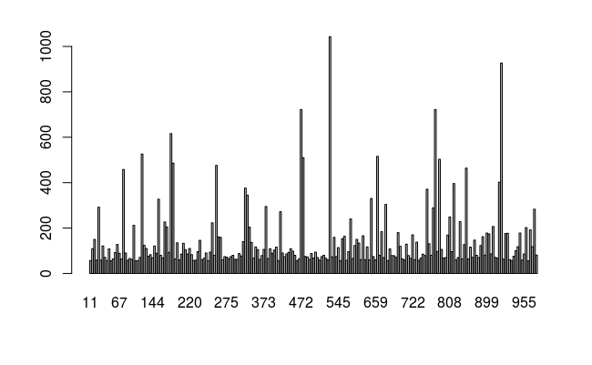

```r
barplot(table(twitter_data_big$story))
```

New boxplot for `twitter_data_big`

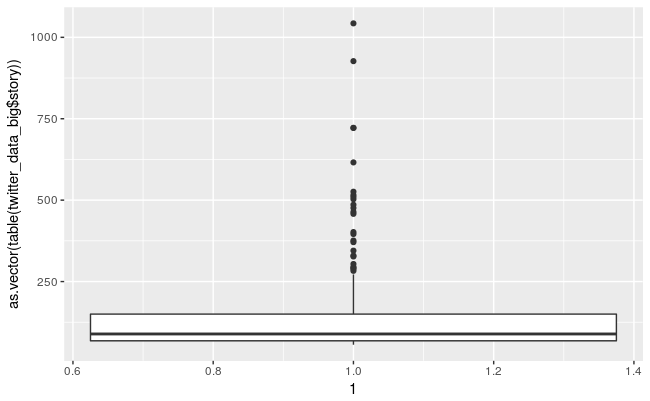

```r
qplot(as.vector(table(twitter_data_big$story)), x= 1, geom = "boxplot")
```

```r
pander(quantile(as.vector(table(twitter_data_big$story))))
```

```
 0%   25%   50%   75%   100%
---- ----- ----- ----- ------
 56   68    89    150   1043
```

So, even if we putted the considered big cascades (more than 55 posts) we still have outliers in the boxplot. We still see that 75% of the cascades (which we considered big) have less than 150 posts while the biggest cascade has 1043 posts.

## `twitter_data_small`

```r
twitter_data_small <- twitter_data[story %in% names(sort(table(twitter_data$story),decreasing = F)[1:sum(table(twitter_data$story)<56)]),]
# re-initialise story factor
twitter_data_small[] <- lapply(twitter_data_small, function(x) if(is.factor(x)) factor(x) else x)
```

Nombre de cascades de `twitter_data_small`: 451.

Nombre de posts de chaque cascade de `twitter_data_small`:

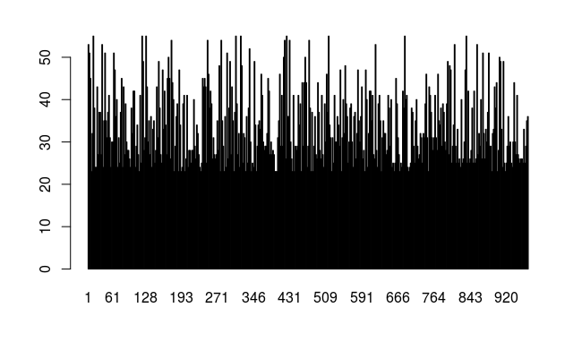

```r
barplot(table(twitter_data_small$story))
```

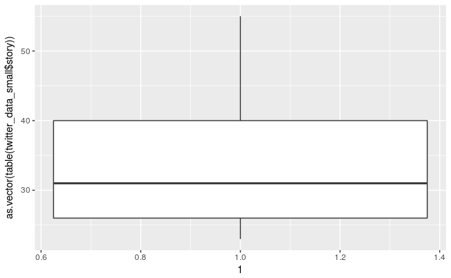

```r
qplot(as.vector(table(twitter_data_small$story)), x= 1, geom = "boxplot")
```

```r
pander(quantile(as.vector(table(twitter_data_small$story))))
```

```
 0%   25%   50%   75%   100%
---- ----- ----- ----- ------
 23   26    31    40     55
```

# 2. Analysis of Twitter data

## Analysis of `twitter_data_small`

> Nous analysons 451 cascades.

**Features**

For every ASI :

Let $s_c$ an ASI discrete time signal of length $T$ ($T$ is not fixed) for the cascade $c$.

- **sumAct** : sum of total activity (number of meme posts)
- **maxAct** : max activity level
- **meanAct** : mean activity level( sumAct/T )
- **varAct** : variance of the activity level $\frac{1}{T}\sum_T (meanAct - s_c(t))^2$
- **actLen** : total activity length, the time between the first and the last observed activity in the signal $s_c$. (**in hours**)
- **peaksNum/actLen** : the ratio of the number of peaks existing in the signal to its active length. As a peak is identified a single value of the signal that is significantly higher than its two neighboring values, the one before and the one after it.
- **maxZeroIntval/actLen** : the ratio of the longest pause of signal where we observe zero values during the active length to that length (actLen).
- **maxNonZeroIntval/actLen** : same as in maxZeroIntval/actLen but for the longest non-zero part of the signal.
- **$V_c$** : number of activated node = $|G_c|$. In addition to ENS’s work :
- **reactions** : somme de likes + shares + retweets + comments + replies + favorites
- **sumImp** : la somme des impressions (distinct users)
- **Sentiment** : $\frac{\# negative}{sumAct} \times (-1)$ + $\frac{\# positive}{sumAct} \times (1)$

```r
data <- twitter_data_small

#création d'une matrice cascades pour faire ACP et Kmeans de ces cascades
cascades <- data.frame(clusterId= integer(0), sumAct= numeric(0), maxAct = numeric(0), meanAct=numeric(0),varAct = numeric(0),actLen = numeric(0),peaksNum_actLen = numeric(0),maxZeroIntval_actLen = numeric(0),maxNonZeroIntval_actLen = numeric(0),V_c = numeric(0),reactions = numeric(0),sumImp = numeric(0),sentiment = numeric(0),stringsAsFactors=FALSE)

ids <- levels(data$story)

for(i in ids){

  #subset du cluster i
  subset <- data[story == i]

  #extraction de dates pour créer ASI (Activity Signal of Interest)
  dates <- as.POSIXct(subset$date,format="%d/%m/%Y %H:%M")
  rounded_dates <- round(dates , "hour")
  rounded_dates <- as.POSIXct(rounded_dates)
  Period_days <- difftime(max(rounded_dates),min(rounded_dates))
  Period_days <- round(Period_days,2)
  Period_hours <- difftime(max(rounded_dates),min(rounded_dates), units = "hours")
  Period_hours <- round(Period_hours,2)
  Occurences <- length(rounded_dates)

  # for ASI that happen in the same hour
  if(Period_hours == 0){
    Period_hours <- 1
  }
  freq <- plyr::count(rounded_dates)

  df1.zoo<-zoo(freq[,-1],freq[,1]) #set date to Index

  df2 <- merge(df1.zoo,zoo(,seq(start(df1.zoo),end(df1.zoo),by="hour")), all=TRUE)

  ASI <- data.frame(Date=time(df2), df2, check.names=FALSE, row.names=NULL)
  colnames(ASI) <- c("date", "freq")
  rm(df1.zoo,df2)
  ASI[is.na(ASI)] <- 0

  #calcul de sumAct
  sumAct <- nrow(subset)

  #calcul de maxAct
  maxAct <- max(ASI$freq)

  #calcul de "meanAct"
  meanAct <- sumAct/as.numeric(Period_hours)

  #calcul de "median-to-mean"
  median_to_mean <- median(ASI$freq)/meanAct

  #calcul de "varAct"
  if(Period_hours == 1){
    varAct <- 0
  } else {
  varAct <- var(ASI$freq)
  }
  #calcul de "actLen"
  actLen <- as.numeric(Period_hours)

  #calcul de "peaksNum/actLen"
  # require(quantmod)
  peaksNum_actLen <- length(findPeaks(ASI$freq))/actLen

  #calcul de "maxZeroIntval/actLen"
  if(Period_hours == 1){
    maxZeroIntval_actLen <- 0
  } else {
  runs <- rle(ASI$freq)
  if(is.infinite(max(runs$lengths[runs$values==0]))){
    maxZeroIntval_actLen <- 0
  } else {
    maxZeroIntval <- max(runs$lengths[runs$values==0])
    maxZeroIntval_actLen <- maxZeroIntval/actLen
  }
  }

  #calcul de "maxNonZeroIntval/actLen"
  runs <- rle(ASI$freq>0)
  maxNonZeroIntval <- max(runs$lengths[runs$values==T])
  maxNonZeroIntval_actLen <- maxNonZeroIntval/actLen

  #calcul de "$V_c$" numbers of nodes (distinct authors in subset)
  V_c <- length(unique(subset$author))

  #calcul de "reactions"
  reactions <- sum(subset$twitter.retweets,na.rm=T) + sum(subset$twitter.replies,na.rm=T) + sum(subset$twitter.favorites,na.rm=T) + sum(subset$web.shares.on.twitter,na.rm=T) + sum(subset$web.comments,na.rm=T) + sum(subset$facebook.likes,na.rm=T) + sum(subset$facebook.shares,na.rm=T) + sum(subset$comments,na.rm=T)

  #calcul de "sumImp"
  sumImp <- sum(subset$impressions,na.rm=T)

  #calcul de sentiment analysis (transformation de 3 facteur negative neutral positive)

  sentiment <- (sum(subset$tone == "positive")/length(subset$tone))*(1) + (sum(subset$tone == "negative")/length(subset$tone))*(-1)

  #insertion dans la matrice finale

      cascades[i,] <- c(i,sumAct,maxAct,meanAct,varAct,actLen,peaksNum_actLen,maxZeroIntval_actLen,maxNonZeroIntval_actLen,V_c,reactions,sumImp,sentiment)

}
```

```r
# to prevent chr in the cascades variables
cascades <- data.matrix(cascades)
```

**Sentiment**

Voici la répartition des valeurs de la variable `sentiment` pour l’ensemble des ASI :

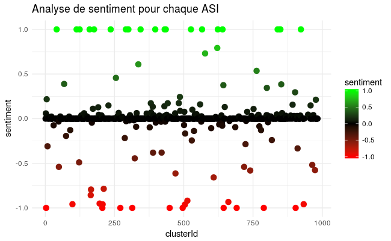

```r
print(ggplot(data=data.table(cascades),
       aes(x=clusterId, y=sentiment)) +
       geom_point(size=3) +
       aes(colour = sentiment) +
       scale_colour_gradientn(colours=c("red","black","green")) +
       theme_minimal() +
       ggtitle("Analyse de sentiment pour chaque ASI")
)
```

**ACP**

**Corrélations**

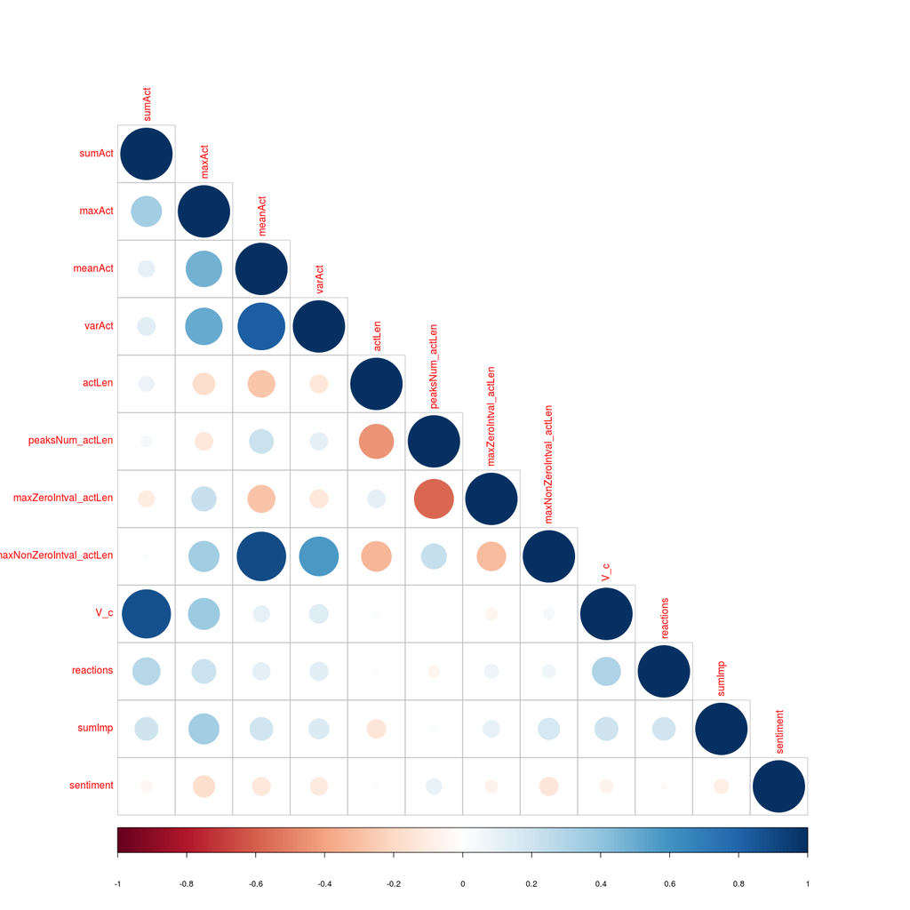

```r
library(corrplot)
corrplot(cor(cascades[,2:ncol(cascades)]), type="lower")
```

**Axes principaux**

Voici les pourcentages que les composantes principales représentent

```r
#ACP
#scaling the matrix
cascades_scaled <- scale(cascades[,2:ncol(cascades)])
acp1 <- princomp(cascades_scaled, scores = TRUE, cor= TRUE)
summary(acp1)
```

```
Importance of components:
                         Comp.1    Comp.2    Comp.3     Comp.4     Comp.5     Comp.6     Comp.7
Standard deviation     1.843462 1.4946449 1.2742063 1.04258633 0.97211223 0.89307499 0.85350286
Proportion of Variance 0.283196 0.1861636 0.1353001 0.09058219 0.07875018 0.06646524 0.06070559
Cumulative Proportion  0.283196 0.4693596 0.6046597 0.69524190 0.77399208 0.84045733 0.90116292
                           Comp.8    Comp.9    Comp.10     Comp.11     Comp.12
Standard deviation     0.67226224 0.5640032 0.51702151 0.343498890 0.175231329
Proportion of Variance 0.03766138 0.0265083 0.02227594 0.009832624 0.002558835
Cumulative Proportion  0.93882430 0.9653326 0.98760854 0.997441165 1.000000000
```

```r
#scree plot
# plot(acp1)
```

Nuage des points (les cascades) sur les deux premiers axes de composantes principales

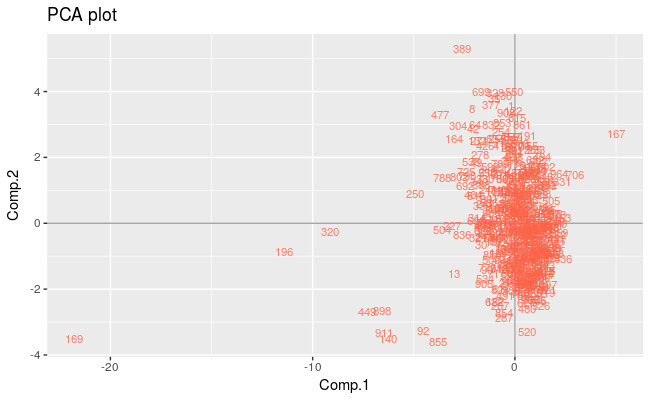

```r
# create data frame with scores
scores = as.data.frame(acp1$scores)
# plot of observations
ggplot(data = scores, aes(x = Comp.1, y = Comp.2, label = rownames(scores))) +
  geom_hline(yintercept = 0, colour = "gray65") +
  geom_vline(xintercept = 0, colour = "gray65") +
  geom_text(colour = "tomato", alpha = 0.8, size = 3) +
  ggtitle("PCA plot")
```

```r
#biplot
# biplot(acp1)
```

```r
# library("devtools")
# install_github("kassambara/factoextra")
# library(factoextra)
# fviz_pca_biplot(acp1)
```

With features:

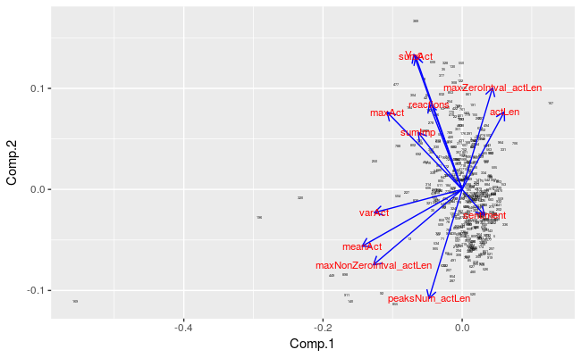

```r
 library(ggfortify)
 autoplot(acp1, label = TRUE, shape = FALSE, label.size = 1, loadings = TRUE, loadings.label = TRUE,  loadings.label.size = 3, loadings.colour = 'blue')
```

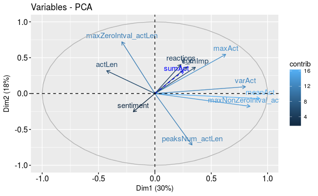

```r
library("FactoMineR")
library("factoextra")
obj    <- PCA(cascades_scaled, graph=F, quanti.sup=1, ind.sup=1)
fviz_pca_var(obj, col.var="contrib")
```

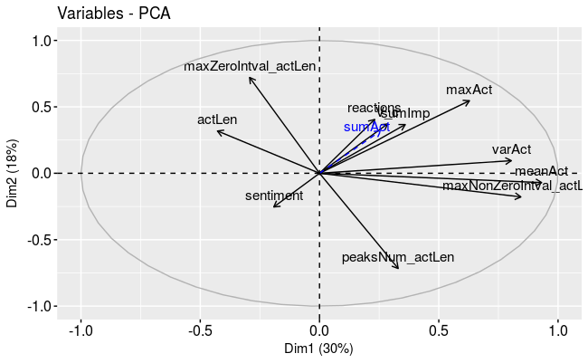

```r
fviz_pca_var(obj)
```

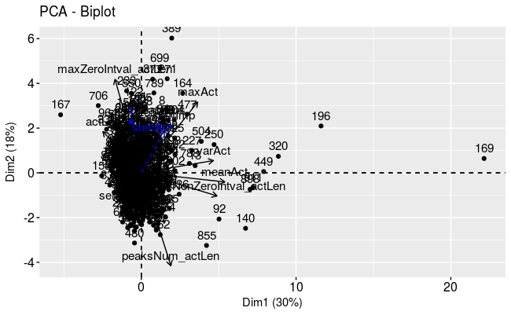

```r
fviz_pca(obj)
```

**KMEANS**

**Nombre de groupes**

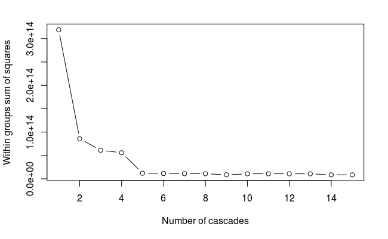

```r
cascades_without_id <- cascades[,2:ncol(cascades)]
wss <- (nrow(cascades_without_id)-1)*sum(apply(cascades_without_id,2,var))
for (i in 2:15) wss[i] <- sum(kmeans(cascades_without_id, centers=i)$withinss)
plot(1:15, wss, type="b", xlab="Number of cascades", ylab="Within groups sum of squares")
```

**Kmeans avec 3 groupes :**

```r
#extraire les comp princ pour visualiser
pc.comp <- acp1$scores
pc.comp1 <- -1*pc.comp[,1] # principal component 1 scores (negated for convenience)
pc.comp2 <- -1*pc.comp[,2]
X <- cbind(pc.comp1, pc.comp2)
cl <- kmeans(cascades_without_id,3)
res <- cbind(clusterId=cascades[,1],kmeans_clusterId=cl$cluster,X)
```

résultats du kmeans avec 3 cascades

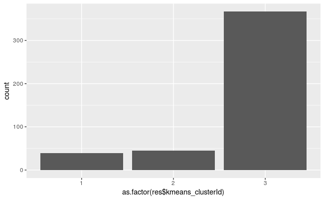

```r
res <- as.data.frame(res)
qplot(as.factor(res$kmeans_clusterId))
```

les groupes obtenus avec le kmeans, le nuage de points correpondant à ce qu’on a obtenu avec l’ACP

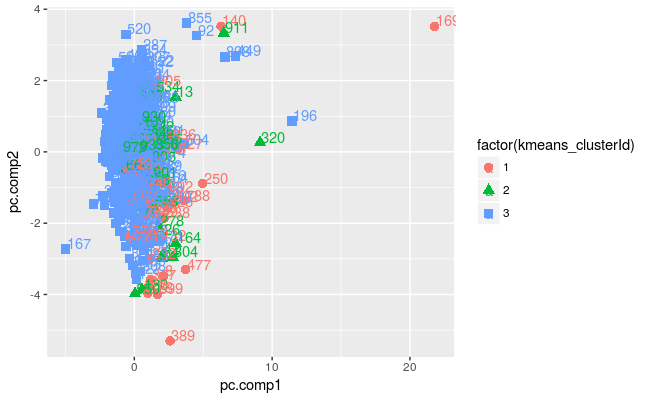

```r
ggplot(res, aes(pc.comp1, pc.comp2,label=clusterId)) +
  geom_point(aes(colour = factor(kmeans_clusterId),shape = factor(kmeans_clusterId)), size =3) +
  geom_text(aes(label=clusterId,colour = factor(kmeans_clusterId)),hjust=0, vjust=0, nudge_x = 0.1)
```

```r
# fviz_cluster(cl, data = cascades)+theme_minimal()+
#   scale_color_manual(values = c("#00AFBB","#2E9FDF", "#E7B800"))+
#   scale_fill_manual(values = c("#00AFBB","#2E9FDF", "#E7B800")) +
#   labs(title= "Partitioning Clustering Plot")
```

**Kmeans avec 4 groupes :**

```r
#extraire les comp princ pour visualiser
pc.comp <- acp1$scores
pc.comp1 <- -1*pc.comp[,1] # principal component 1 scores (negated for convenience)
pc.comp2 <- -1*pc.comp[,2]
X <- cbind(pc.comp1, pc.comp2)
cl <- kmeans(cascades_without_id,4)
res <- cbind(clusterId=cascades[,1],kmeans_clusterId=cl$cluster,X)
```

résultats du kmeans avec 4 groupes

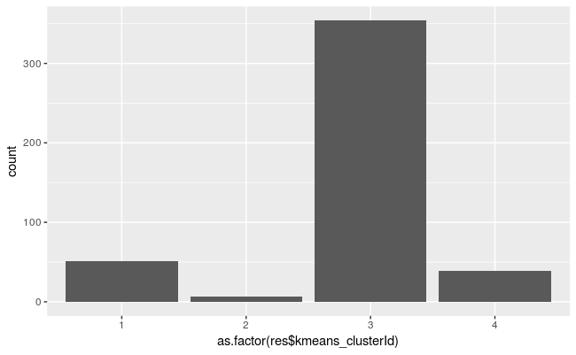

```r
res <- as.data.frame(res)
qplot(as.factor(res$kmeans_clusterId))
```

les groupes obtenus avec le kmeans, le nuage de points correpondant à ce qu’on a obtenu avec l’ACP

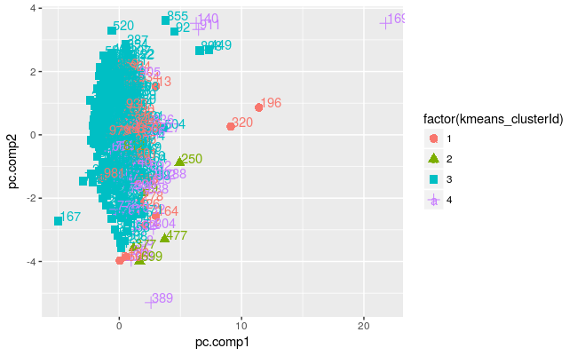

```r
ggplot(res, aes(pc.comp1, pc.comp2,label=clusterId)) +
  geom_point(aes(colour = factor(kmeans_clusterId),shape = factor(kmeans_clusterId)), size =3) +
  geom_text(aes(label=clusterId,colour = factor(kmeans_clusterId)),hjust=0, vjust=0, nudge_x = 0.1)
```

## Analysis of `twitter_data_big`

> Nous analysons 217 cascades.

```r
data <- twitter_data_big

#création d'une matrice cascades pour faire ACP et Kmeans de ces cascades
cascades <- data.frame(clusterId= integer(0), sumAct= numeric(0), maxAct = numeric(0), meanAct=numeric(0),varAct = numeric(0),actLen = numeric(0),peaksNum_actLen = numeric(0),maxZeroIntval_actLen = numeric(0),maxNonZeroIntval_actLen = numeric(0),V_c = numeric(0),reactions = numeric(0),sumImp = numeric(0),sentiment = numeric(0),stringsAsFactors=FALSE)

ids <- levels(data$story)

for(i in ids){

  #subset du cluster i
  subset <- data[story == i]

  #extraction de dates pour créer ASI (Activity Signal of Interest)
  dates <- as.POSIXct(subset$date,format="%d/%m/%Y %H:%M")
  rounded_dates <- round(dates , "hour")
  rounded_dates <- as.POSIXct(rounded_dates)
  Period_days <- difftime(max(rounded_dates),min(rounded_dates))
  Period_days <- round(Period_days,2)
  Period_hours <- difftime(max(rounded_dates),min(rounded_dates), units = "hours")
  Period_hours <- round(Period_hours,2)
  Occurences <- length(rounded_dates)

  # for ASI that happen in the same hour
  if(Period_hours == 0){
    Period_hours <- 1
  }
  freq <- plyr::count(rounded_dates)

  df1.zoo<-zoo(freq[,-1],freq[,1]) #set date to Index

  df2 <- merge(df1.zoo,zoo(,seq(start(df1.zoo),end(df1.zoo),by="hour")), all=TRUE)

  ASI <- data.frame(Date=time(df2), df2, check.names=FALSE, row.names=NULL)
  colnames(ASI) <- c("date", "freq")
  rm(df1.zoo,df2)
  ASI[is.na(ASI)] <- 0

  #calcul de sumAct
  sumAct <- nrow(subset)

  #calcul de maxAct
  maxAct <- max(ASI$freq)

  #calcul de "meanAct"
  meanAct <- sumAct/as.numeric(Period_hours)

  #calcul de "median-to-mean"
  median_to_mean <- median(ASI$freq)/meanAct

  #calcul de "varAct"
  if(Period_hours == 1){
    varAct <- 0
  } else {
  varAct <- var(ASI$freq)
  }
  #calcul de "actLen"
  actLen <- as.numeric(Period_hours)

  #calcul de "peaksNum/actLen"
  # require(quantmod)
  peaksNum_actLen <- length(findPeaks(ASI$freq))/actLen

  #calcul de "maxZeroIntval/actLen"
  if(Period_hours == 1){
    maxZeroIntval_actLen <- 0
  } else {
  runs <- rle(ASI$freq)
  if(is.infinite(max(runs$lengths[runs$values==0]))){
    maxZeroIntval_actLen <- 0
  } else {
    maxZeroIntval <- max(runs$lengths[runs$values==0])
    maxZeroIntval_actLen <- maxZeroIntval/actLen
  }
  }

  #calcul de "maxNonZeroIntval/actLen"
  runs <- rle(ASI$freq>0)
  maxNonZeroIntval <- max(runs$lengths[runs$values==T])
  maxNonZeroIntval_actLen <- maxNonZeroIntval/actLen

  #calcul de "$V_c$" numbers of nodes (distinct authors in subset)
  V_c <- length(unique(subset$author))

  #calcul de "reactions"
  reactions <- sum(subset$twitter.retweets,na.rm=T) + sum(subset$twitter.replies,na.rm=T) + sum(subset$twitter.favorites,na.rm=T) + sum(subset$web.shares.on.twitter,na.rm=T) + sum(subset$web.comments,na.rm=T) + sum(subset$facebook.likes,na.rm=T) + sum(subset$facebook.shares,na.rm=T) + sum(subset$comments,na.rm=T)

  #calcul de "sumImp"
  sumImp <- sum(subset$impressions,na.rm=T)

  #calcul de sentiment analysis (transformation de 3 facteur negative neutral positive)

  sentiment <- (sum(subset$tone == "positive")/length(subset$tone))*(1) + (sum(subset$tone == "negative")/length(subset$tone))*(-1)

  #insertion dans la matrice finale

      cascades[i,] <- c(i,sumAct,maxAct,meanAct,varAct,actLen,peaksNum_actLen,maxZeroIntval_actLen,maxNonZeroIntval_actLen,V_c,reactions,sumImp,sentiment)

}
```

```r
# to prevent chr in the cascades variables
cascades <- data.matrix(cascades)
```

**Sentiment**

Voici la répartition des valeurs de la variable `sentiment` pour l’ensemble des ASI :

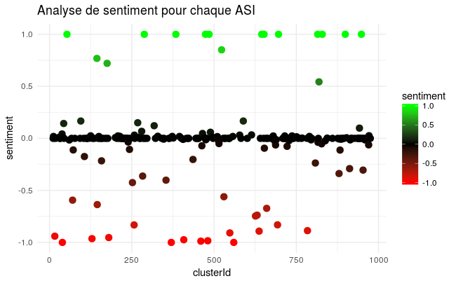

```r
print(ggplot(data=data.table(cascades),
       aes(x=clusterId, y=sentiment)) +
       geom_point(size=3) +
       aes(colour = sentiment) +
       scale_colour_gradientn(colours=c("red","black","green")) +
       theme_minimal() +
       ggtitle("Analyse de sentiment pour chaque ASI")
)
```

**ACP**

**Corrélations**

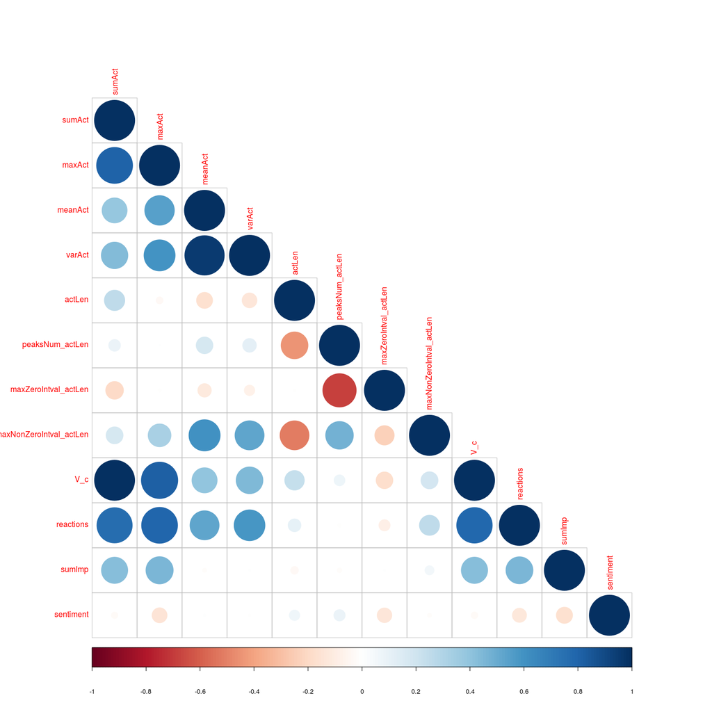

```r
library(corrplot)
corrplot(cor(cascades[,2:ncol(cascades)]), type="lower")
```

**Axes principaux**

Voici les pourcentages que les composantes principales représentent

```r
#ACP
#scaling the matrix
cascades_scaled <- scale(cascades[,2:ncol(cascades)])
acp1 <- princomp(cascades_scaled, scores = TRUE, cor= TRUE)
summary(acp1)
```

```
Importance of components:
                          Comp.1    Comp.2    Comp.3    Comp.4     Comp.5     Comp.6     Comp.7
Standard deviation     2.1680890 1.5359062 1.2297299 1.1244263 0.90618419 0.66845160 0.57823510
Proportion of Variance 0.3917175 0.1965840 0.1260196 0.1053612 0.06843082 0.03723563 0.02786299
Cumulative Proportion  0.3917175 0.5883015 0.7143211 0.8196823 0.88811312 0.92534875 0.95321174
                           Comp.8     Comp.9     Comp.10     Comp.11      Comp.12
Standard deviation     0.47457611 0.42823978 0.338509611 0.179783910 0.0770477339
Proportion of Variance 0.01876854 0.01528244 0.009549063 0.002693521 0.0004946961
Cumulative Proportion  0.97198028 0.98726272 0.996811783 0.999505304 1.0000000000
```

```r
#scree plot
# plot(acp1)
```

Nuage des points (les cascades) sur les deux premiers axes de composantes principales

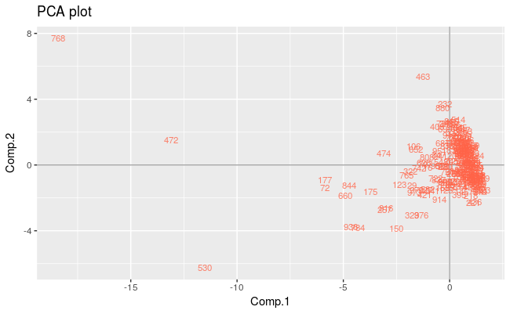

```r
# create data frame with scores
scores = as.data.frame(acp1$scores)
# plot of observations
ggplot(data = scores, aes(x = Comp.1, y = Comp.2, label = rownames(scores))) +
  geom_hline(yintercept = 0, colour = "gray65") +
  geom_vline(xintercept = 0, colour = "gray65") +
  geom_text(colour = "tomato", alpha = 0.8, size = 3) +
  ggtitle("PCA plot")
```

```r
#biplot
# biplot(acp1)
```

```r
# library("devtools")
# install_github("kassambara/factoextra")
# library(factoextra)
# fviz_pca_biplot(acp1)
```

With features:

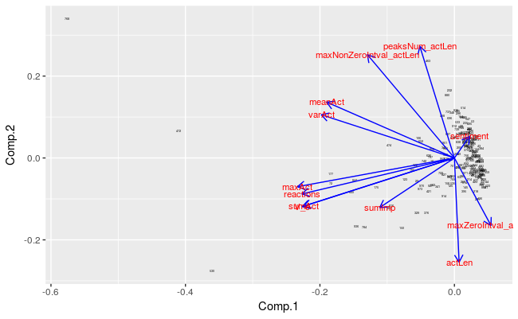

```r
 library(ggfortify)
 autoplot(acp1, label = TRUE, shape = FALSE, label.size = 1, loadings = TRUE, loadings.label = TRUE,  loadings.label.size = 3, loadings.colour = 'blue')
```

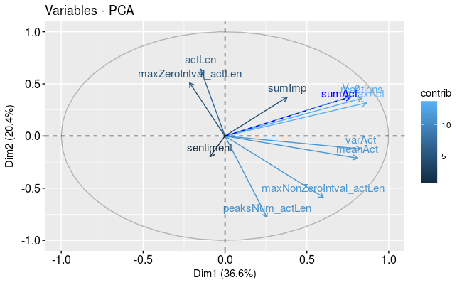

```r
library("FactoMineR")
library("factoextra")
obj    <- PCA(cascades_scaled, graph=F, quanti.sup=1, ind.sup=1)
fviz_pca_var(obj, col.var="contrib")
```

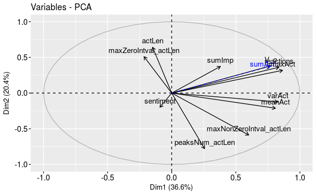

```r
fviz_pca_var(obj)
```

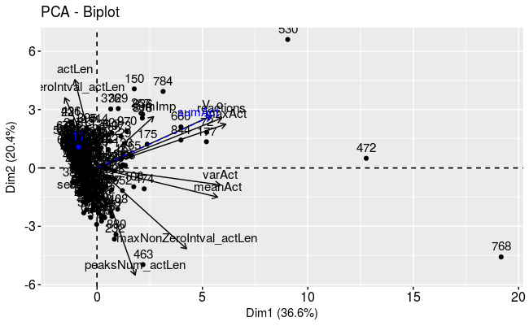

```r
fviz_pca(obj)
```

**KMEANS**

**Nombre de groupes**

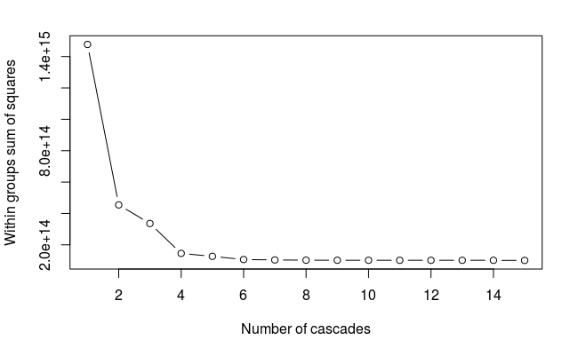

```r
cascades_without_id <- cascades[,2:ncol(cascades)]
wss <- (nrow(cascades_without_id)-1)*sum(apply(cascades_without_id,2,var))
for (i in 2:15) wss[i] <- sum(kmeans(cascades_without_id, centers=i)$withinss)
plot(1:15, wss, type="b", xlab="Number of cascades", ylab="Within groups sum of squares")
```

**Kmeans avec 3 groupes :**

```r
#extraire les comp princ pour visualiser
pc.comp <- acp1$scores
pc.comp1 <- -1*pc.comp[,1] # principal component 1 scores (negated for convenience)
pc.comp2 <- -1*pc.comp[,2]
X <- cbind(pc.comp1, pc.comp2)
cl <- kmeans(cascades_without_id,3)
res <- cbind(clusterId=cascades[,1],kmeans_clusterId=cl$cluster,X)
```

résultats du kmeans avec 3 cascades

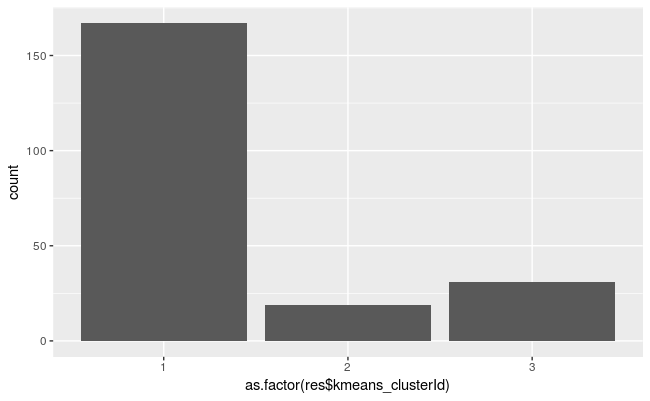

```r
res <- as.data.frame(res)
qplot(as.factor(res$kmeans_clusterId))
```

les groupes obtenus avec le kmeans, le nuage de points correpondant à ce qu’on a obtenu avec l’ACP

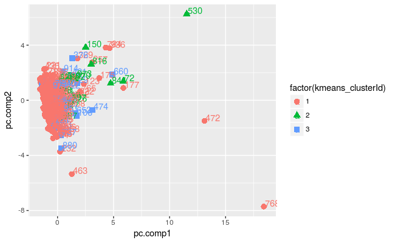

```r
ggplot(res, aes(pc.comp1, pc.comp2,label=clusterId)) +
  geom_point(aes(colour = factor(kmeans_clusterId),shape = factor(kmeans_clusterId)), size =3) +
  geom_text(aes(label=clusterId,colour = factor(kmeans_clusterId)),hjust=0, vjust=0, nudge_x = 0.1)
```

```r
# fviz_cluster(cl, data = cascades)+theme_minimal()+
#   scale_color_manual(values = c("#00AFBB","#2E9FDF", "#E7B800"))+
#   scale_fill_manual(values = c("#00AFBB","#2E9FDF", "#E7B800")) +
#   labs(title= "Partitioning Clustering Plot")
```

**Kmeans avec 4 groupes :**

```r
#extraire les comp princ pour visualiser
pc.comp <- acp1$scores
pc.comp1 <- -1*pc.comp[,1] # principal component 1 scores (negated for convenience)
pc.comp2 <- -1*pc.comp[,2]
X <- cbind(pc.comp1, pc.comp2)
cl <- kmeans(cascades_without_id,4)
res <- cbind(clusterId=cascades[,1],kmeans_clusterId=cl$cluster,X)
```

résultats du kmeans avec 4 groupes

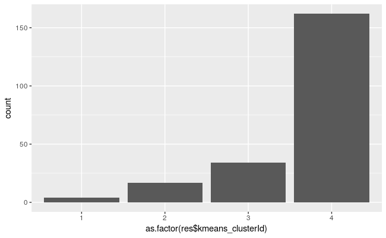

```r
res <- as.data.frame(res)
qplot(as.factor(res$kmeans_clusterId))
```

les groupes obtenus avec le kmeans, le nuage de points correpondant à ce qu’on a obtenu avec l’ACP

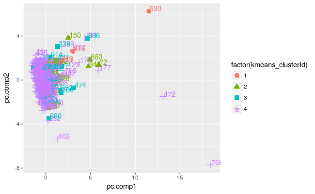

```r
ggplot(res, aes(pc.comp1, pc.comp2,label=clusterId)) +
  geom_point(aes(colour = factor(kmeans_clusterId),shape = factor(kmeans_clusterId)), size =3) +
  geom_text(aes(label=clusterId,colour = factor(kmeans_clusterId)),hjust=0, vjust=0, nudge_x = 0.1)
```